# Risk Factor Analysis

## Outcome Variable

**Outcome Variable:** stunted

## Predictor Variables

**Intervention Variable:** feducyrs

**Adjustment Set:**

unadjusted

## Stratifying Variables

The analysis was stratified on these variable(s):

- agecat
- studyid
- country

## Data Summary

| agecat | studyid | country | A | n | nA | nAY0 | nAY1 |
| --- | --- | --- | --- | --- | --- | --- | --- |
| Birth | ki0047075b-MAL-ED | BANGLADESH | Q4 | 144 | 52 | 44 | 8 |
| Birth | ki0047075b-MAL-ED | BANGLADESH | Q1 | 144 | 29 | 24 | 5 |
| Birth | ki0047075b-MAL-ED | BANGLADESH | Q2 | 144 | 9 | 6 | 3 |
| Birth | ki0047075b-MAL-ED | BANGLADESH | Q3 | 144 | 54 | 44 | 10 |
| Birth | ki0047075b-MAL-ED | INDIA | Q4 | 123 | 38 | 32 | 6 |
| Birth | ki0047075b-MAL-ED | INDIA | Q1 | 123 | 21 | 20 | 1 |
| Birth | ki0047075b-MAL-ED | INDIA | Q2 | 123 | 37 | 33 | 4 |
| Birth | ki0047075b-MAL-ED | INDIA | Q3 | 123 | 27 | 23 | 4 |
| Birth | ki0047075b-MAL-ED | NEPAL | Q4 | 67 | 27 | 26 | 1 |
| Birth | ki0047075b-MAL-ED | NEPAL | Q1 | 67 | 18 | 16 | 2 |
| Birth | ki0047075b-MAL-ED | NEPAL | Q2 | 67 | 17 | 13 | 4 |
| Birth | ki0047075b-MAL-ED | NEPAL | Q3 | 67 | 5 | 4 | 1 |
| Birth | ki0047075b-MAL-ED | PERU | Q4 | 236 | 116 | 106 | 10 |
| Birth | ki0047075b-MAL-ED | PERU | Q1 | 236 | 47 | 37 | 10 |
| Birth | ki0047075b-MAL-ED | PERU | Q2 | 236 | 62 | 56 | 6 |
| Birth | ki0047075b-MAL-ED | PERU | Q3 | 236 | 11 | 11 | 0 |
| Birth | ki0047075b-MAL-ED | SOUTH AFRICA | Q4 | 91 | 35 | 30 | 5 |
| Birth | ki0047075b-MAL-ED | SOUTH AFRICA | Q1 | 91 | 15 | 15 | 0 |
| Birth | ki0047075b-MAL-ED | SOUTH AFRICA | Q2 | 91 | 22 | 22 | 0 |
| Birth | ki0047075b-MAL-ED | SOUTH AFRICA | Q3 | 91 | 19 | 16 | 3 |
| Birth | ki0047075b-MAL-ED | TANZANIA, UNITED REPUBLIC OF | Q4 | 101 | 3 | 3 | 0 |
| Birth | ki0047075b-MAL-ED | TANZANIA, UNITED REPUBLIC OF | Q1 | 101 | 20 | 18 | 2 |
| Birth | ki0047075b-MAL-ED | TANZANIA, UNITED REPUBLIC OF | Q2 | 101 | 16 | 11 | 5 |
| Birth | ki0047075b-MAL-ED | TANZANIA, UNITED REPUBLIC OF | Q3 | 101 | 62 | 54 | 8 |
| Birth | ki1000304b-SAS-CompFeed | INDIA | Q4 | 70 | 11 | 11 | 0 |
| Birth | ki1000304b-SAS-CompFeed | INDIA | Q1 | 70 | 11 | 6 | 5 |
| Birth | ki1000304b-SAS-CompFeed | INDIA | Q2 | 70 | 26 | 17 | 9 |
| Birth | ki1000304b-SAS-CompFeed | INDIA | Q3 | 70 | 22 | 19 | 3 |
| Birth | ki1017093c-NIH-Crypto | BANGLADESH | Q4 | 27 | 5 | 5 | 0 |
| Birth | ki1017093c-NIH-Crypto | BANGLADESH | Q1 | 27 | 4 | 3 | 1 |

[output cut: 486 more lines]

The following strata were considered:

- agecat: 12 months, studyid: ki0047075b-MAL-ED, country: BANGLADESH
- agecat: 12 months, studyid: ki0047075b-MAL-ED, country: INDIA
- agecat: 12 months, studyid: ki0047075b-MAL-ED, country: NEPAL
- agecat: 12 months, studyid: ki0047075b-MAL-ED, country: PERU
- agecat: 12 months, studyid: ki0047075b-MAL-ED, country: SOUTH AFRICA
- agecat: 12 months, studyid: ki0047075b-MAL-ED, country: TANZANIA, UNITED REPUBLIC OF
- agecat: 12 months, studyid: ki1000304b-SAS-CompFeed, country: INDIA
- agecat: 12 months, studyid: ki1000304b-SAS-FoodSuppl, country: INDIA
- agecat: 12 months, studyid: ki1017093b-PROVIDE, country: BANGLADESH
- agecat: 12 months, studyid: ki1017093c-NIH-Crypto, country: BANGLADESH
- agecat: 12 months, studyid: ki1066203-TanzaniaChild2, country: TANZANIA, UNITED REPUBLIC OF
- agecat: 12 months, studyid: ki1113344-GMS-Nepal, country: NEPAL
- agecat: 12 months, studyid: ki1119695-PROBIT, country: BELARUS
- agecat: 12 months, studyid: ki1126311-ZVITAMBO, country: ZIMBABWE
- agecat: 12 months, studyid: ki1135781-COHORTS, country: GUATEMALA
- agecat: 12 months, studyid: ki1135781-COHORTS, country: INDIA
- agecat: 12 months, studyid: ki1135781-COHORTS, country: PHILIPPINES
- agecat: 12 months, studyid: ki1148112-LCNI-5, country: MALAWI
- agecat: 12 months, studyid: kiGH5241-JiVitA-3, country: BANGLADESH
- agecat: 12 months, studyid: kiGH5241-JiVitA-4, country: BANGLADESH
- agecat: 18 months, studyid: ki0047075b-MAL-ED, country: BANGLADESH
- agecat: 18 months, studyid: ki0047075b-MAL-ED, country: INDIA
- agecat: 18 months, studyid: ki0047075b-MAL-ED, country: NEPAL
- agecat: 18 months, studyid: ki0047075b-MAL-ED, country: PERU
- agecat: 18 months, studyid: ki0047075b-MAL-ED, country: SOUTH AFRICA
- agecat: 18 months, studyid: ki0047075b-MAL-ED, country: TANZANIA, UNITED REPUBLIC OF
- agecat: 18 months, studyid: ki1000304b-SAS-CompFeed, country: INDIA
- agecat: 18 months, studyid: ki1000304b-SAS-FoodSuppl, country: INDIA
- agecat: 18 months, studyid: ki1017093b-PROVIDE, country: BANGLADESH
- agecat: 18 months, studyid: ki1017093c-NIH-Crypto, country: BANGLADESH
- agecat: 18 months, studyid: ki1066203-TanzaniaChild2, country: TANZANIA, UNITED REPUBLIC OF
- agecat: 18 months, studyid: ki1113344-GMS-Nepal, country: NEPAL
- agecat: 18 months, studyid: ki1119695-PROBIT, country: BELARUS
- agecat: 18 months, studyid: ki1126311-ZVITAMBO, country: ZIMBABWE
- agecat: 18 months, studyid: ki1135781-COHORTS, country: GUATEMALA
- agecat: 18 months, studyid: ki1135781-COHORTS, country: PHILIPPINES
- agecat: 18 months, studyid: ki1148112-LCNI-5, country: MALAWI
- agecat: 18 months, studyid: kiGH5241-JiVitA-4, country: BANGLADESH
- agecat: 24 months, studyid: ki0047075b-MAL-ED, country: BANGLADESH
- agecat: 24 months, studyid: ki0047075b-MAL-ED, country: INDIA
- agecat: 24 months, studyid: ki0047075b-MAL-ED, country: NEPAL
- agecat: 24 months, studyid: ki0047075b-MAL-ED, country: PERU
- agecat: 24 months, studyid: ki0047075b-MAL-ED, country: SOUTH AFRICA
- agecat: 24 months, studyid: ki0047075b-MAL-ED, country: TANZANIA, UNITED REPUBLIC OF
- agecat: 24 months, studyid: ki1017093b-PROVIDE, country: BANGLADESH
- agecat: 24 months, studyid: ki1017093c-NIH-Crypto, country: BANGLADESH
- agecat: 24 months, studyid: ki1066203-TanzaniaChild2, country: TANZANIA, UNITED REPUBLIC OF
- agecat: 24 months, studyid: ki1113344-GMS-Nepal, country: NEPAL
- agecat: 24 months, studyid: ki1119695-PROBIT, country: BELARUS
- agecat: 24 months, studyid: ki1126311-ZVITAMBO, country: ZIMBABWE
- agecat: 24 months, studyid: ki1135781-COHORTS, country: GUATEMALA
- agecat: 24 months, studyid: ki1135781-COHORTS, country: INDIA
- agecat: 24 months, studyid: ki1135781-COHORTS, country: PHILIPPINES
- agecat: 24 months, studyid: ki1148112-LCNI-5, country: MALAWI
- agecat: 24 months, studyid: kiGH5241-JiVitA-3, country: BANGLADESH
- agecat: 24 months, studyid: kiGH5241-JiVitA-4, country: BANGLADESH
- agecat: 3 months, studyid: ki0047075b-MAL-ED, country: BANGLADESH
- agecat: 3 months, studyid: ki0047075b-MAL-ED, country: INDIA
- agecat: 3 months, studyid: ki0047075b-MAL-ED, country: NEPAL
- agecat: 3 months, studyid: ki0047075b-MAL-ED, country: PERU
- agecat: 3 months, studyid: ki0047075b-MAL-ED, country: SOUTH AFRICA
- agecat: 3 months, studyid: ki0047075b-MAL-ED, country: TANZANIA, UNITED REPUBLIC OF
- agecat: 3 months, studyid: ki1000304b-SAS-CompFeed, country: INDIA
- agecat: 3 months, studyid: ki1000304b-SAS-FoodSuppl, country: INDIA
- agecat: 3 months, studyid: ki1017093b-PROVIDE, country: BANGLADESH
- agecat: 3 months, studyid: ki1017093c-NIH-Crypto, country: BANGLADESH
- agecat: 3 months, studyid: ki1066203-TanzaniaChild2, country: TANZANIA, UNITED REPUBLIC OF
- agecat: 3 months, studyid: ki1113344-GMS-Nepal, country: NEPAL
- agecat: 3 months, studyid: ki1119695-PROBIT, country: BELARUS
- agecat: 3 months, studyid: ki1126311-ZVITAMBO, country: ZIMBABWE
- agecat: 3 months, studyid: ki1135781-COHORTS, country: GUATEMALA
- agecat: 3 months, studyid: ki1135781-COHORTS, country: INDIA
- agecat: 3 months, studyid: ki1135781-COHORTS, country: PHILIPPINES
- agecat: 3 months, studyid: kiGH5241-JiVitA-3, country: BANGLADESH
- agecat: 3 months, studyid: kiGH5241-JiVitA-4, country: BANGLADESH
- agecat: 6 months, studyid: ki0047075b-MAL-ED, country: BANGLADESH
- agecat: 6 months, studyid: ki0047075b-MAL-ED, country: INDIA
- agecat: 6 months, studyid: ki0047075b-MAL-ED, country: NEPAL
- agecat: 6 months, studyid: ki0047075b-MAL-ED, country: PERU
- agecat: 6 months, studyid: ki0047075b-MAL-ED, country: SOUTH AFRICA
- agecat: 6 months, studyid: ki0047075b-MAL-ED, country: TANZANIA, UNITED REPUBLIC OF
- agecat: 6 months, studyid: ki1000304b-SAS-CompFeed, country: INDIA
- agecat: 6 months, studyid: ki1000304b-SAS-FoodSuppl, country: INDIA
- agecat: 6 months, studyid: ki1017093b-PROVIDE, country: BANGLADESH
- agecat: 6 months, studyid: ki1017093c-NIH-Crypto, country: BANGLADESH
- agecat: 6 months, studyid: ki1066203-TanzaniaChild2, country: TANZANIA, UNITED REPUBLIC OF
- agecat: 6 months, studyid: ki1113344-GMS-Nepal, country: NEPAL
- agecat: 6 months, studyid: ki1119695-PROBIT, country: BELARUS
- agecat: 6 months, studyid: ki1126311-ZVITAMBO, country: ZIMBABWE
- agecat: 6 months, studyid: ki1135781-COHORTS, country: GUATEMALA
- agecat: 6 months, studyid: ki1135781-COHORTS, country: INDIA
- agecat: 6 months, studyid: ki1135781-COHORTS, country: PHILIPPINES
- agecat: 6 months, studyid: ki1148112-LCNI-5, country: MALAWI
- agecat: 6 months, studyid: kiGH5241-JiVitA-3, country: BANGLADESH
- agecat: 6 months, studyid: kiGH5241-JiVitA-4, country: BANGLADESH
- agecat: 9 months, studyid: ki0047075b-MAL-ED, country: BANGLADESH
- agecat: 9 months, studyid: ki0047075b-MAL-ED, country: INDIA
- agecat: 9 months, studyid: ki0047075b-MAL-ED, country: NEPAL
- agecat: 9 months, studyid: ki0047075b-MAL-ED, country: PERU
- agecat: 9 months, studyid: ki0047075b-MAL-ED, country: SOUTH AFRICA
- agecat: 9 months, studyid: ki0047075b-MAL-ED, country: TANZANIA, UNITED REPUBLIC OF
- agecat: 9 months, studyid: ki1000304b-SAS-CompFeed, country: INDIA
- agecat: 9 months, studyid: ki1000304b-SAS-FoodSuppl, country: INDIA
- agecat: 9 months, studyid: ki1017093b-PROVIDE, country: BANGLADESH
- agecat: 9 months, studyid: ki1017093c-NIH-Crypto, country: BANGLADESH
- agecat: 9 months, studyid: ki1066203-TanzaniaChild2, country: TANZANIA, UNITED REPUBLIC OF
- agecat: 9 months, studyid: ki1113344-GMS-Nepal, country: NEPAL
- agecat: 9 months, studyid: ki1119695-PROBIT, country: BELARUS
- agecat: 9 months, studyid: ki1126311-ZVITAMBO, country: ZIMBABWE
- agecat: 9 months, studyid: ki1135781-COHORTS, country: GUATEMALA
- agecat: 9 months, studyid: ki1135781-COHORTS, country: INDIA
- agecat: 9 months, studyid: ki1135781-COHORTS, country: PHILIPPINES
- agecat: 9 months, studyid: ki1148112-LCNI-5, country: MALAWI
- agecat: 9 months, studyid: kiGH5241-JiVitA-4, country: BANGLADESH
- agecat: Birth, studyid: ki0047075b-MAL-ED, country: BANGLADESH
- agecat: Birth, studyid: ki0047075b-MAL-ED, country: INDIA
- agecat: Birth, studyid: ki0047075b-MAL-ED, country: NEPAL
- agecat: Birth, studyid: ki0047075b-MAL-ED, country: PERU
- agecat: Birth, studyid: ki0047075b-MAL-ED, country: SOUTH AFRICA
- agecat: Birth, studyid: ki0047075b-MAL-ED, country: TANZANIA, UNITED REPUBLIC OF
- agecat: Birth, studyid: ki1000304b-SAS-CompFeed, country: INDIA
- agecat: Birth, studyid: ki1017093c-NIH-Crypto, country: BANGLADESH
- agecat: Birth, studyid: ki1119695-PROBIT, country: BELARUS
- agecat: Birth, studyid: ki1126311-ZVITAMBO, country: ZIMBABWE
- agecat: Birth, studyid: ki1135781-COHORTS, country: GUATEMALA
- agecat: Birth, studyid: ki1135781-COHORTS, country: INDIA
- agecat: Birth, studyid: ki1135781-COHORTS, country: PHILIPPINES
- agecat: Birth, studyid: kiGH5241-JiVitA-3, country: BANGLADESH
- agecat: Birth, studyid: kiGH5241-JiVitA-4, country: BANGLADESH

### Dropped Strata

Some strata were dropped due to rare outcomes:

- agecat: Birth, studyid: ki0047075b-MAL-ED, country: BANGLADESH
- agecat: Birth, studyid: ki0047075b-MAL-ED, country: INDIA
- agecat: Birth, studyid: ki0047075b-MAL-ED, country: NEPAL
- agecat: Birth, studyid: ki0047075b-MAL-ED, country: PERU
- agecat: Birth, studyid: ki0047075b-MAL-ED, country: SOUTH AFRICA
- agecat: Birth, studyid: ki0047075b-MAL-ED, country: TANZANIA, UNITED REPUBLIC OF
- agecat: Birth, studyid: ki1000304b-SAS-CompFeed, country: INDIA
- agecat: Birth, studyid: ki1017093c-NIH-Crypto, country: BANGLADESH
- agecat: Birth, studyid: ki1119695-PROBIT, country: BELARUS
- agecat: Birth, studyid: ki1135781-COHORTS, country: GUATEMALA
- agecat: Birth, studyid: kiGH5241-JiVitA-4, country: BANGLADESH
- agecat: 3 months, studyid: ki0047075b-MAL-ED, country: BANGLADESH
- agecat: 3 months, studyid: ki0047075b-MAL-ED, country: INDIA
- agecat: 3 months, studyid: ki0047075b-MAL-ED, country: NEPAL
- agecat: 3 months, studyid: ki0047075b-MAL-ED, country: PERU
- agecat: 3 months, studyid: ki0047075b-MAL-ED, country: SOUTH AFRICA
- agecat: 3 months, studyid: ki0047075b-MAL-ED, country: TANZANIA, UNITED REPUBLIC OF
- agecat: 3 months, studyid: ki1000304b-SAS-FoodSuppl, country: INDIA
- agecat: 3 months, studyid: ki1017093b-PROVIDE, country: BANGLADESH
- agecat: 3 months, studyid: ki1066203-TanzaniaChild2, country: TANZANIA, UNITED REPUBLIC OF
- agecat: 3 months, studyid: ki1119695-PROBIT, country: BELARUS
- agecat: 3 months, studyid: ki1135781-COHORTS, country: GUATEMALA
- agecat: 3 months, studyid: kiGH5241-JiVitA-4, country: BANGLADESH
- agecat: 6 months, studyid: ki0047075b-MAL-ED, country: BANGLADESH
- agecat: 6 months, studyid: ki0047075b-MAL-ED, country: INDIA
- agecat: 6 months, studyid: ki0047075b-MAL-ED, country: NEPAL
- agecat: 6 months, studyid: ki0047075b-MAL-ED, country: PERU
- agecat: 6 months, studyid: ki0047075b-MAL-ED, country: SOUTH AFRICA
- agecat: 6 months, studyid: ki0047075b-MAL-ED, country: TANZANIA, UNITED REPUBLIC OF
- agecat: 6 months, studyid: ki1000304b-SAS-FoodSuppl, country: INDIA
- agecat: 6 months, studyid: ki1017093b-PROVIDE, country: BANGLADESH
- agecat: 6 months, studyid: ki1066203-TanzaniaChild2, country: TANZANIA, UNITED REPUBLIC OF
- agecat: 6 months, studyid: ki1119695-PROBIT, country: BELARUS
- agecat: 6 months, studyid: ki1135781-COHORTS, country: GUATEMALA
- agecat: 6 months, studyid: kiGH5241-JiVitA-4, country: BANGLADESH
- agecat: 9 months, studyid: ki0047075b-MAL-ED, country: BANGLADESH
- agecat: 9 months, studyid: ki0047075b-MAL-ED, country: INDIA
- agecat: 9 months, studyid: ki0047075b-MAL-ED, country: NEPAL
- agecat: 9 months, studyid: ki0047075b-MAL-ED, country: PERU
- agecat: 9 months, studyid: ki0047075b-MAL-ED, country: SOUTH AFRICA
- agecat: 9 months, studyid: ki0047075b-MAL-ED, country: TANZANIA, UNITED REPUBLIC OF
- agecat: 9 months, studyid: ki1000304b-SAS-FoodSuppl, country: INDIA
- agecat: 9 months, studyid: ki1017093b-PROVIDE, country: BANGLADESH
- agecat: 9 months, studyid: ki1066203-TanzaniaChild2, country: TANZANIA, UNITED REPUBLIC OF
- agecat: 9 months, studyid: ki1119695-PROBIT, country: BELARUS
- agecat: 9 months, studyid: ki1135781-COHORTS, country: GUATEMALA
- agecat: 9 months, studyid: kiGH5241-JiVitA-4, country: BANGLADESH
- agecat: 12 months, studyid: ki0047075b-MAL-ED, country: BANGLADESH
- agecat: 12 months, studyid: ki0047075b-MAL-ED, country: NEPAL
- agecat: 12 months, studyid: ki0047075b-MAL-ED, country: PERU
- agecat: 12 months, studyid: ki0047075b-MAL-ED, country: SOUTH AFRICA
- agecat: 12 months, studyid: ki0047075b-MAL-ED, country: TANZANIA, UNITED REPUBLIC OF
- agecat: 12 months, studyid: ki1000304b-SAS-FoodSuppl, country: INDIA
- agecat: 12 months, studyid: ki1017093b-PROVIDE, country: BANGLADESH
- agecat: 12 months, studyid: ki1066203-TanzaniaChild2, country: TANZANIA, UNITED REPUBLIC OF
- agecat: 12 months, studyid: ki1119695-PROBIT, country: BELARUS
- agecat: 12 months, studyid: ki1135781-COHORTS, country: GUATEMALA
- agecat: 12 months, studyid: kiGH5241-JiVitA-4, country: BANGLADESH
- agecat: 18 months, studyid: ki0047075b-MAL-ED, country: BANGLADESH
- agecat: 18 months, studyid: ki0047075b-MAL-ED, country: NEPAL
- agecat: 18 months, studyid: ki0047075b-MAL-ED, country: PERU
- agecat: 18 months, studyid: ki0047075b-MAL-ED, country: TANZANIA, UNITED REPUBLIC OF
- agecat: 18 months, studyid: ki1000304b-SAS-FoodSuppl, country: INDIA
- agecat: 18 months, studyid: ki1017093b-PROVIDE, country: BANGLADESH
- agecat: 18 months, studyid: ki1066203-TanzaniaChild2, country: TANZANIA, UNITED REPUBLIC OF
- agecat: 18 months, studyid: ki1119695-PROBIT, country: BELARUS
- agecat: 18 months, studyid: ki1135781-COHORTS, country: GUATEMALA
- agecat: 18 months, studyid: kiGH5241-JiVitA-4, country: BANGLADESH
- agecat: 24 months, studyid: ki0047075b-MAL-ED, country: BANGLADESH
- agecat: 24 months, studyid: ki0047075b-MAL-ED, country: NEPAL
- agecat: 24 months, studyid: ki0047075b-MAL-ED, country: PERU
- agecat: 24 months, studyid: ki0047075b-MAL-ED, country: TANZANIA, UNITED REPUBLIC OF
- agecat: 24 months, studyid: ki1017093b-PROVIDE, country: BANGLADESH
- agecat: 24 months, studyid: ki1066203-TanzaniaChild2, country: TANZANIA, UNITED REPUBLIC OF
- agecat: 24 months, studyid: ki1119695-PROBIT, country: BELARUS
- agecat: 24 months, studyid: ki1126311-ZVITAMBO, country: ZIMBABWE
- agecat: 24 months, studyid: ki1135781-COHORTS, country: GUATEMALA
- agecat: 24 months, studyid: kiGH5241-JiVitA-4, country: BANGLADESH

## Methods Detail

We’re interested in the causal parameters $E[Y_a]$ for all values of $a \in \mathcal{A}$. These parameters represent the mean outcome if, possibly contrary to fact, we intervened to set all units to have $A=a$. Under the randomization and positivity assumptions, these are identified by the statistical parameters $\psi_a=E_W[E_{Y|A,W}(Y|A=a,W)]$. In addition, we’re interested in the mean of $Y$, $E[Y]$ under no intervention (the observed mean). We will estimate these parameters by using SuperLearner to fit the relevant likelihood factors – $E_{Y|A,W}(Y|A=a,W)$ and $p(A=a|W)$, and then updating our likelihood fit using a joint TMLE.

For unadjusted analyses ($W=\{\}$), initial likelihoods were estimated using Lrnr_glm to estimate the simple $E(Y|A)$ and Lrnr_mean to estimate $p(A)$. For adjusted analyses, a small library containing Lrnr_glmnet, Lrnr_xgboost, and Lrnr_mean was used.

Having estimated these parameters, we will then use the delta method to estimate relative risks and attributable risks relative to a prespecified baseline level of $A$.

# Results Detail

## Results Plots

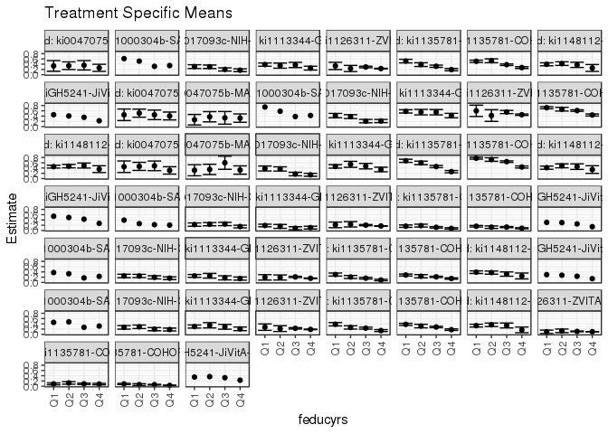

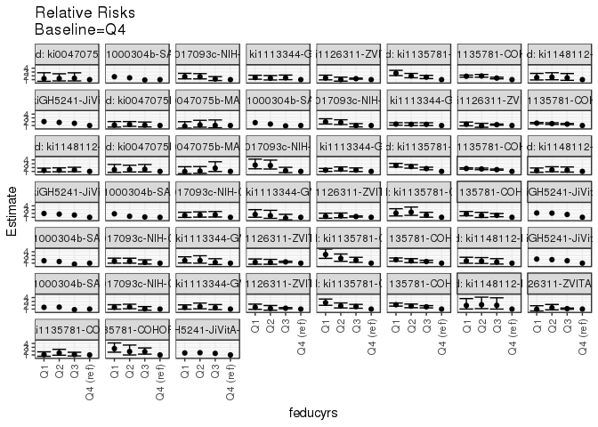

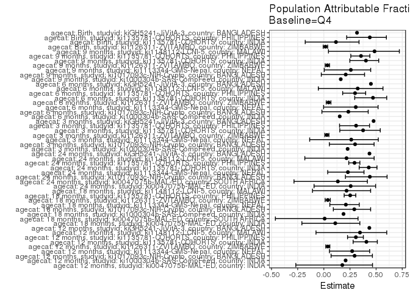

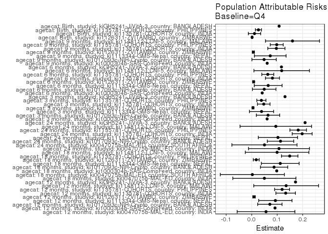

## Results Table

### Parameter: TSM

| agecat | studyid | country | intervention_level | baseline_level | estimate | ci_lower | ci_upper |
| --- | --- | --- | --- | --- | --- | --- | --- |
| Birth | ki1126311-ZVITAMBO | ZIMBABWE | Q4 | NA | 0.1013561 | 0.0958409 | 0.1068712 |
| Birth | ki1126311-ZVITAMBO | ZIMBABWE | Q1 | NA | 0.0975610 | 0.0333360 | 0.1617860 |
| Birth | ki1126311-ZVITAMBO | ZIMBABWE | Q2 | NA | 0.1340206 | 0.0662225 | 0.2018188 |
| Birth | ki1126311-ZVITAMBO | ZIMBABWE | Q3 | NA | 0.1119865 | 0.0973238 | 0.1266492 |
| Birth | ki1135781-COHORTS | INDIA | Q4 | NA | 0.0842105 | 0.0562788 | 0.1121423 |
| Birth | ki1135781-COHORTS | INDIA | Q1 | NA | 0.0909091 | 0.0546758 | 0.1271424 |
| Birth | ki1135781-COHORTS | INDIA | Q2 | NA | 0.1269036 | 0.0804046 | 0.1734025 |
| Birth | ki1135781-COHORTS | INDIA | Q3 | NA | 0.0934579 | 0.0687843 | 0.1181316 |
| Birth | ki1135781-COHORTS | PHILIPPINES | Q4 | NA | 0.0337349 | 0.0214500 | 0.0460199 |
| Birth | ki1135781-COHORTS | PHILIPPINES | Q1 | NA | 0.0898876 | 0.0674242 | 0.1123511 |
| Birth | ki1135781-COHORTS | PHILIPPINES | Q2 | NA | 0.0637255 | 0.0302006 | 0.0972503 |
| Birth | ki1135781-COHORTS | PHILIPPINES | Q3 | NA | 0.0625000 | 0.0488924 | 0.0761076 |
| Birth | kiGH5241-JiVitA-3 | BANGLADESH | Q4 | NA | 0.2314939 | NA | NA |
| Birth | kiGH5241-JiVitA-3 | BANGLADESH | Q1 | NA | 0.3507917 | NA | NA |
| Birth | kiGH5241-JiVitA-3 | BANGLADESH | Q2 | NA | 0.3660765 | NA | NA |
| Birth | kiGH5241-JiVitA-3 | BANGLADESH | Q3 | NA | 0.3261649 | NA | NA |
| 3 months | ki1000304b-SAS-CompFeed | INDIA | Q4 | NA | 0.2053571 | NA | NA |
| 3 months | ki1000304b-SAS-CompFeed | INDIA | Q1 | NA | 0.3936170 | NA | NA |
| 3 months | ki1000304b-SAS-CompFeed | INDIA | Q2 | NA | 0.2600000 | NA | NA |
| 3 months | ki1000304b-SAS-CompFeed | INDIA | Q3 | NA | 0.2211538 | NA | NA |
| 3 months | ki1017093c-NIH-Crypto | BANGLADESH | Q4 | NA | 0.1502591 | 0.0998125 | 0.2007056 |
| 3 months | ki1017093c-NIH-Crypto | BANGLADESH | Q1 | NA | 0.2248521 | 0.1618661 | 0.2878381 |
| 3 months | ki1017093c-NIH-Crypto | BANGLADESH | Q2 | NA | 0.2393617 | 0.1783260 | 0.3003974 |
| 3 months | ki1017093c-NIH-Crypto | BANGLADESH | Q3 | NA | 0.2471910 | 0.1837755 | 0.3106065 |
| 3 months | ki1113344-GMS-Nepal | NEPAL | Q4 | NA | 0.1086957 | 0.0567189 | 0.1606724 |
| 3 months | ki1113344-GMS-Nepal | NEPAL | Q1 | NA | 0.1895161 | 0.1406960 | 0.2383362 |
| 3 months | ki1113344-GMS-Nepal | NEPAL | Q2 | NA | 0.1555556 | 0.0806116 | 0.2304995 |
| 3 months | ki1113344-GMS-Nepal | NEPAL | Q3 | NA | 0.0851064 | 0.0286476 | 0.1415652 |
| 3 months | ki1126311-ZVITAMBO | ZIMBABWE | Q4 | NA | 0.1710336 | 0.1625649 | 0.1795023 |
| 3 months | ki1126311-ZVITAMBO | ZIMBABWE | Q1 | NA | 0.2142857 | 0.1068107 | 0.3217607 |

[output cut: 174 more lines]

### Parameter: E(Y)

| agecat | studyid | country | intervention_level | baseline_level | estimate | ci_lower | ci_upper |
| --- | --- | --- | --- | --- | --- | --- | --- |
| Birth | ki1126311-ZVITAMBO | ZIMBABWE | NA | NA | 0.1029718 | 0.0978372 | 0.1081063 |
| Birth | ki1135781-COHORTS | INDIA | NA | NA | 0.0952733 | 0.0796294 | 0.1109171 |
| Birth | ki1135781-COHORTS | PHILIPPINES | NA | NA | 0.0602158 | 0.0515157 | 0.0689159 |
| Birth | kiGH5241-JiVitA-3 | BANGLADESH | NA | NA | 0.3390590 | NA | NA |
| 3 months | ki1000304b-SAS-CompFeed | INDIA | NA | NA | 0.2658537 | NA | NA |
| 3 months | ki1017093c-NIH-Crypto | BANGLADESH | NA | NA | 0.2142857 | 0.1844587 | 0.2441127 |
| 3 months | ki1113344-GMS-Nepal | NEPAL | NA | NA | 0.1473684 | 0.1182428 | 0.1764940 |
| 3 months | ki1126311-ZVITAMBO | ZIMBABWE | NA | NA | 0.1762134 | 0.1683068 | 0.1841201 |
| 3 months | ki1135781-COHORTS | INDIA | NA | NA | 0.1259843 | 0.1085773 | 0.1433912 |
| 3 months | ki1135781-COHORTS | PHILIPPINES | NA | NA | 0.1232978 | 0.1109330 | 0.1356625 |
| 3 months | kiGH5241-JiVitA-3 | BANGLADESH | NA | NA | 0.2747642 | NA | NA |
| 6 months | ki1000304b-SAS-CompFeed | INDIA | NA | NA | 0.2713936 | NA | NA |
| 6 months | ki1017093c-NIH-Crypto | BANGLADESH | NA | NA | 0.2097902 | 0.1799252 | 0.2396552 |
| 6 months | ki1113344-GMS-Nepal | NEPAL | NA | NA | 0.2117438 | 0.1779368 | 0.2455507 |
| 6 months | ki1126311-ZVITAMBO | ZIMBABWE | NA | NA | 0.1645789 | 0.1564849 | 0.1726730 |
| 6 months | ki1135781-COHORTS | INDIA | NA | NA | 0.1732852 | 0.1533446 | 0.1932258 |
| 6 months | ki1135781-COHORTS | PHILIPPINES | NA | NA | 0.2113885 | 0.1955816 | 0.2271953 |
| 6 months | ki1148112-LCNI-5 | MALAWI | NA | NA | 0.3633005 | 0.3301997 | 0.3964012 |
| 6 months | kiGH5241-JiVitA-3 | BANGLADESH | NA | NA | 0.2592732 | NA | NA |
| 9 months | ki1000304b-SAS-CompFeed | INDIA | NA | NA | 0.3756219 | NA | NA |
| 9 months | ki1017093c-NIH-Crypto | BANGLADESH | NA | NA | 0.2322946 | 0.2011222 | 0.2634670 |
| 9 months | ki1113344-GMS-Nepal | NEPAL | NA | NA | 0.2818182 | 0.2441856 | 0.3194507 |
| 9 months | ki1126311-ZVITAMBO | ZIMBABWE | NA | NA | 0.1944109 | 0.1854196 | 0.2034021 |
| 9 months | ki1135781-COHORTS | INDIA | NA | NA | 0.2404459 | 0.2168022 | 0.2640895 |
| 9 months | ki1135781-COHORTS | PHILIPPINES | NA | NA | 0.2760234 | 0.2587203 | 0.2933265 |
| 9 months | ki1148112-LCNI-5 | MALAWI | NA | NA | 0.3302752 | 0.2942026 | 0.3663478 |
| 12 months | ki0047075b-MAL-ED | INDIA | NA | NA | 0.3181818 | 0.2384220 | 0.3979417 |
| 12 months | ki1000304b-SAS-CompFeed | INDIA | NA | NA | 0.4393204 | NA | NA |
| 12 months | ki1017093c-NIH-Crypto | BANGLADESH | NA | NA | 0.2422096 | 0.2105851 | 0.2738341 |
| 12 months | ki1113344-GMS-Nepal | NEPAL | NA | NA | 0.3429084 | 0.3034525 | 0.3823644 |
| 12 months | ki1126311-ZVITAMBO | ZIMBABWE | NA | NA | 0.2423271 | 0.2319485 | 0.2527056 |
| 12 months | ki1135781-COHORTS | INDIA | NA | NA | 0.3274262 | 0.3006962 | 0.3541562 |
| 12 months | ki1135781-COHORTS | PHILIPPINES | NA | NA | 0.3890478 | 0.3697270 | 0.4083686 |
| 12 months | ki1148112-LCNI-5 | MALAWI | NA | NA | 0.3909532 | 0.3524814 | 0.4294249 |
| 12 months | kiGH5241-JiVitA-3 | BANGLADESH | NA | NA | 0.3950029 | NA | NA |
| 18 months | ki0047075b-MAL-ED | INDIA | NA | NA | 0.4545455 | 0.3692786 | 0.5398123 |
| 18 months | ki0047075b-MAL-ED | SOUTH AFRICA | NA | NA | 0.3260870 | 0.2297715 | 0.4224024 |
| 18 months | ki1000304b-SAS-CompFeed | INDIA | NA | NA | 0.5216285 | NA | NA |
| 18 months | ki1017093c-NIH-Crypto | BANGLADESH | NA | NA | 0.3012618 | 0.2655201 | 0.3370036 |
| 18 months | ki1113344-GMS-Nepal | NEPAL | NA | NA | 0.5318761 | 0.4900985 | 0.5736537 |
| 18 months | ki1126311-ZVITAMBO | ZIMBABWE | NA | NA | 0.4704449 | 0.4462882 | 0.4946015 |
| 18 months | ki1135781-COHORTS | PHILIPPINES | NA | NA | 0.5915074 | 0.5716503 | 0.6113646 |
| 18 months | ki1148112-LCNI-5 | MALAWI | NA | NA | 0.4581006 | 0.4215802 | 0.4946209 |
| 24 months | ki0047075b-MAL-ED | INDIA | NA | NA | 0.4166667 | 0.3322428 | 0.5010905 |
| 24 months | ki0047075b-MAL-ED | SOUTH AFRICA | NA | NA | 0.3736264 | 0.2736811 | 0.4735717 |
| 24 months | ki1017093c-NIH-Crypto | BANGLADESH | NA | NA | 0.2568093 | 0.2190047 | 0.2946140 |
| 24 months | ki1113344-GMS-Nepal | NEPAL | NA | NA | 0.4477912 | 0.4040733 | 0.4915091 |
| 24 months | ki1135781-COHORTS | INDIA | NA | NA | 0.4608696 | 0.4345607 | 0.4871784 |
| 24 months | ki1135781-COHORTS | PHILIPPINES | NA | NA | 0.6214347 | 0.6016683 | 0.6412012 |
| 24 months | ki1148112-LCNI-5 | MALAWI | NA | NA | 0.4360771 | 0.3953670 | 0.4767872 |
| 24 months | kiGH5241-JiVitA-3 | BANGLADESH | NA | NA | 0.4797478 | NA | NA |

### Parameter: RR

| agecat | studyid | country | intervention_level | baseline_level | estimate | ci_lower | ci_upper |
| --- | --- | --- | --- | --- | --- | --- | --- |
| Birth | ki1126311-ZVITAMBO | ZIMBABWE | Q4 | Q4 | 1.0000000 | 1.0000000 | 1.000000 |
| Birth | ki1126311-ZVITAMBO | ZIMBABWE | Q1 | Q4 | 0.9625570 | 0.4972246 | 1.863375 |
| Birth | ki1126311-ZVITAMBO | ZIMBABWE | Q2 | Q4 | 1.3222755 | 0.7949766 | 2.199326 |
| Birth | ki1126311-ZVITAMBO | ZIMBABWE | Q3 | Q4 | 1.1048822 | 0.9588214 | 1.273193 |
| Birth | ki1135781-COHORTS | INDIA | Q4 | Q4 | 1.0000000 | 1.0000000 | 1.000000 |
| Birth | ki1135781-COHORTS | INDIA | Q1 | Q4 | 1.0795455 | 0.6427563 | 1.813157 |
| Birth | ki1135781-COHORTS | INDIA | Q2 | Q4 | 1.5069797 | 0.9193073 | 2.470325 |
| Birth | ki1135781-COHORTS | INDIA | Q3 | Q4 | 1.1098131 | 0.7263378 | 1.695747 |
| Birth | ki1135781-COHORTS | PHILIPPINES | Q4 | Q4 | 1.0000000 | 1.0000000 | 1.000000 |
| Birth | ki1135781-COHORTS | PHILIPPINES | Q1 | Q4 | 2.6645265 | 1.7132011 | 4.144114 |
| Birth | ki1135781-COHORTS | PHILIPPINES | Q2 | Q4 | 1.8890056 | 0.9962332 | 3.581834 |
| Birth | ki1135781-COHORTS | PHILIPPINES | Q3 | Q4 | 1.8526786 | 1.2120945 | 2.831807 |
| Birth | kiGH5241-JiVitA-3 | BANGLADESH | Q4 | Q4 | 1.0000000 | NA | NA |
| Birth | kiGH5241-JiVitA-3 | BANGLADESH | Q1 | Q4 | 1.5153386 | NA | NA |
| Birth | kiGH5241-JiVitA-3 | BANGLADESH | Q2 | Q4 | 1.5813655 | NA | NA |
| Birth | kiGH5241-JiVitA-3 | BANGLADESH | Q3 | Q4 | 1.4089564 | NA | NA |
| 3 months | ki1000304b-SAS-CompFeed | INDIA | Q4 | Q4 | 1.0000000 | NA | NA |
| 3 months | ki1000304b-SAS-CompFeed | INDIA | Q1 | Q4 | 1.9167438 | NA | NA |
| 3 months | ki1000304b-SAS-CompFeed | INDIA | Q2 | Q4 | 1.2660870 | NA | NA |
| 3 months | ki1000304b-SAS-CompFeed | INDIA | Q3 | Q4 | 1.0769231 | NA | NA |
| 3 months | ki1017093c-NIH-Crypto | BANGLADESH | Q4 | Q4 | 1.0000000 | 1.0000000 | 1.000000 |
| 3 months | ki1017093c-NIH-Crypto | BANGLADESH | Q1 | Q4 | 1.4964293 | 0.9664137 | 2.317124 |
| 3 months | ki1017093c-NIH-Crypto | BANGLADESH | Q2 | Q4 | 1.5929934 | 1.0450100 | 2.428329 |
| 3 months | ki1017093c-NIH-Crypto | BANGLADESH | Q3 | Q4 | 1.6450988 | 1.0781777 | 2.510115 |
| 3 months | ki1113344-GMS-Nepal | NEPAL | Q4 | Q4 | 1.0000000 | 1.0000000 | 1.000000 |
| 3 months | ki1113344-GMS-Nepal | NEPAL | Q1 | Q4 | 1.7435484 | 1.0128452 | 3.001407 |
| 3 months | ki1113344-GMS-Nepal | NEPAL | Q2 | Q4 | 1.4311111 | 0.7258922 | 2.821464 |
| 3 months | ki1113344-GMS-Nepal | NEPAL | Q3 | Q4 | 0.7829787 | 0.3456181 | 1.773795 |
| 3 months | ki1126311-ZVITAMBO | ZIMBABWE | Q4 | Q4 | 1.0000000 | 1.0000000 | 1.000000 |
| 3 months | ki1126311-ZVITAMBO | ZIMBABWE | Q1 | Q4 | 1.2528868 | 0.7568897 | 2.073916 |

[output cut: 174 more lines]

### Parameter: PAR

| agecat | studyid | country | intervention_level | baseline_level | estimate | ci_lower | ci_upper |
| --- | --- | --- | --- | --- | --- | --- | --- |
| Birth | ki1126311-ZVITAMBO | ZIMBABWE | Q4 | NA | 0.0016157 | -0.0005722 | 0.0038037 |
| Birth | ki1135781-COHORTS | INDIA | Q4 | NA | 0.0110627 | -0.0131653 | 0.0352907 |
| Birth | ki1135781-COHORTS | PHILIPPINES | Q4 | NA | 0.0264809 | 0.0146736 | 0.0382881 |
| Birth | kiGH5241-JiVitA-3 | BANGLADESH | Q4 | NA | 0.1075651 | NA | NA |
| 3 months | ki1000304b-SAS-CompFeed | INDIA | Q4 | NA | 0.0604965 | NA | NA |
| 3 months | ki1017093c-NIH-Crypto | BANGLADESH | Q4 | NA | 0.0640266 | 0.0183629 | 0.1096903 |
| 3 months | ki1113344-GMS-Nepal | NEPAL | Q4 | NA | 0.0386728 | -0.0086743 | 0.0860199 |
| 3 months | ki1126311-ZVITAMBO | ZIMBABWE | Q4 | NA | 0.0051799 | 0.0016990 | 0.0086607 |
| 3 months | ki1135781-COHORTS | INDIA | Q4 | NA | 0.0473040 | 0.0225790 | 0.0720291 |
| 3 months | ki1135781-COHORTS | PHILIPPINES | Q4 | NA | 0.0380264 | 0.0201516 | 0.0559013 |
| 3 months | kiGH5241-JiVitA-3 | BANGLADESH | Q4 | NA | 0.1307093 | NA | NA |
| 6 months | ki1000304b-SAS-CompFeed | INDIA | Q4 | NA | 0.0413051 | NA | NA |
| 6 months | ki1017093c-NIH-Crypto | BANGLADESH | Q4 | NA | 0.0491684 | 0.0030335 | 0.0953034 |
| 6 months | ki1113344-GMS-Nepal | NEPAL | Q4 | NA | 0.0646849 | 0.0101470 | 0.1192229 |
| 6 months | ki1126311-ZVITAMBO | ZIMBABWE | Q4 | NA | 0.0075445 | 0.0038585 | 0.0112305 |
| 6 months | ki1135781-COHORTS | INDIA | Q4 | NA | 0.0814485 | 0.0540159 | 0.1088810 |
| 6 months | ki1135781-COHORTS | PHILIPPINES | Q4 | NA | 0.0631367 | 0.0396841 | 0.0865893 |
| 6 months | ki1148112-LCNI-5 | MALAWI | Q4 | NA | 0.1176865 | 0.0088607 | 0.2265122 |
| 6 months | kiGH5241-JiVitA-3 | BANGLADESH | Q4 | NA | 0.1167293 | NA | NA |
| 9 months | ki1000304b-SAS-CompFeed | INDIA | Q4 | NA | 0.0608071 | NA | NA |
| 9 months | ki1017093c-NIH-Crypto | BANGLADESH | Q4 | NA | 0.0486211 | 0.0008658 | 0.0963765 |
| 9 months | ki1113344-GMS-Nepal | NEPAL | Q4 | NA | 0.0728630 | 0.0108128 | 0.1349131 |
| 9 months | ki1126311-ZVITAMBO | ZIMBABWE | Q4 | NA | 0.0066227 | 0.0025534 | 0.0106919 |
| 9 months | ki1135781-COHORTS | INDIA | Q4 | NA | 0.0967839 | 0.0630468 | 0.1305209 |
| 9 months | ki1135781-COHORTS | PHILIPPINES | Q4 | NA | 0.0981522 | 0.0726908 | 0.1236137 |
| 9 months | ki1148112-LCNI-5 | MALAWI | Q4 | NA | 0.1600625 | 0.0542269 | 0.2658980 |
| 12 months | ki0047075b-MAL-ED | INDIA | Q4 | NA | 0.0562771 | -0.0570371 | 0.1695913 |
| 12 months | ki1000304b-SAS-CompFeed | INDIA | Q4 | NA | 0.0914943 | NA | NA |
| 12 months | ki1017093c-NIH-Crypto | BANGLADESH | Q4 | NA | 0.0712252 | 0.0234682 | 0.1189821 |
| 12 months | ki1113344-GMS-Nepal | NEPAL | Q4 | NA | 0.0929084 | 0.0275516 | 0.1582653 |
| 12 months | ki1126311-ZVITAMBO | ZIMBABWE | Q4 | NA | 0.0092593 | 0.0045315 | 0.0139872 |
| 12 months | ki1135781-COHORTS | INDIA | Q4 | NA | 0.1333085 | 0.0949894 | 0.1716277 |
| 12 months | ki1135781-COHORTS | PHILIPPINES | Q4 | NA | 0.1192531 | 0.0898488 | 0.1486574 |
| 12 months | ki1148112-LCNI-5 | MALAWI | Q4 | NA | 0.1351392 | 0.0080640 | 0.2622144 |
| 12 months | kiGH5241-JiVitA-3 | BANGLADESH | Q4 | NA | 0.1719058 | NA | NA |
| 18 months | ki0047075b-MAL-ED | INDIA | Q4 | NA | 0.0497835 | -0.0740905 | 0.1736576 |
| 18 months | ki0047075b-MAL-ED | SOUTH AFRICA | Q4 | NA | 0.0025575 | -0.1231334 | 0.1282485 |
| 18 months | ki1000304b-SAS-CompFeed | INDIA | Q4 | NA | 0.0982051 | NA | NA |
| 18 months | ki1017093c-NIH-Crypto | BANGLADESH | Q4 | NA | 0.0877787 | 0.0342165 | 0.1413409 |
| 18 months | ki1113344-GMS-Nepal | NEPAL | Q4 | NA | 0.1120288 | 0.0379604 | 0.1860972 |
| 18 months | ki1126311-ZVITAMBO | ZIMBABWE | Q4 | NA | 0.0177976 | 0.0062635 | 0.0293317 |
| 18 months | ki1135781-COHORTS | PHILIPPINES | Q4 | NA | 0.1491111 | 0.1167778 | 0.1814445 |
| 18 months | ki1148112-LCNI-5 | MALAWI | Q4 | NA | 0.0996100 | -0.0251079 | 0.2243279 |
| 24 months | ki0047075b-MAL-ED | INDIA | Q4 | NA | 0.1071429 | -0.0123971 | 0.2266828 |
| 24 months | ki0047075b-MAL-ED | SOUTH AFRICA | Q4 | NA | 0.0500970 | -0.0776070 | 0.1778009 |
| 24 months | ki1017093c-NIH-Crypto | BANGLADESH | Q4 | NA | 0.1130185 | 0.0612255 | 0.1648114 |
| 24 months | ki1113344-GMS-Nepal | NEPAL | Q4 | NA | 0.1029636 | 0.0260513 | 0.1798759 |
| 24 months | ki1135781-COHORTS | INDIA | Q4 | NA | 0.1979830 | 0.1588362 | 0.2371297 |
| 24 months | ki1135781-COHORTS | PHILIPPINES | Q4 | NA | 0.1823722 | 0.1499445 | 0.2148000 |
| 24 months | ki1148112-LCNI-5 | MALAWI | Q4 | NA | 0.0946136 | -0.0458569 | 0.2350842 |
| 24 months | kiGH5241-JiVitA-3 | BANGLADESH | Q4 | NA | 0.2094128 | NA | NA |

### Parameter: PAF

| agecat | studyid | country | intervention_level | baseline_level | estimate | ci_lower | ci_upper |
| --- | --- | --- | --- | --- | --- | --- | --- |
| Birth | ki1126311-ZVITAMBO | ZIMBABWE | Q4 | NA | 0.0156909 | -0.0057768 | 0.0367003 |
| Birth | ki1135781-COHORTS | INDIA | Q4 | NA | 0.1161159 | -0.1777657 | 0.3366668 |
| Birth | ki1135781-COHORTS | PHILIPPINES | Q4 | NA | 0.4397660 | 0.2187758 | 0.5982432 |
| Birth | kiGH5241-JiVitA-3 | BANGLADESH | Q4 | NA | 0.3172458 | NA | NA |
| 3 months | ki1000304b-SAS-CompFeed | INDIA | Q4 | NA | 0.2275557 | NA | NA |
| 3 months | ki1017093c-NIH-Crypto | BANGLADESH | Q4 | NA | 0.2987910 | 0.0531787 | 0.4806897 |
| 3 months | ki1113344-GMS-Nepal | NEPAL | Q4 | NA | 0.2624224 | -0.1353717 | 0.5208434 |
| 3 months | ki1126311-ZVITAMBO | ZIMBABWE | Q4 | NA | 0.0293953 | 0.0094656 | 0.0489240 |
| 3 months | ki1135781-COHORTS | INDIA | Q4 | NA | 0.3754759 | 0.1526604 | 0.5397001 |
| 3 months | ki1135781-COHORTS | PHILIPPINES | Q4 | NA | 0.3084114 | 0.1504248 | 0.4370189 |
| 3 months | kiGH5241-JiVitA-3 | BANGLADESH | Q4 | NA | 0.4757144 | NA | NA |
| 6 months | ki1000304b-SAS-CompFeed | INDIA | Q4 | NA | 0.1521964 | NA | NA |
| 6 months | ki1017093c-NIH-Crypto | BANGLADESH | Q4 | NA | 0.2343696 | -0.0183695 | 0.4243839 |
| 6 months | ki1113344-GMS-Nepal | NEPAL | Q4 | NA | 0.3054869 | -0.0021242 | 0.5186740 |
| 6 months | ki1126311-ZVITAMBO | ZIMBABWE | Q4 | NA | 0.0458412 | 0.0232525 | 0.0679075 |
| 6 months | ki1135781-COHORTS | INDIA | Q4 | NA | 0.4700255 | 0.2953820 | 0.6013826 |
| 6 months | ki1135781-COHORTS | PHILIPPINES | Q4 | NA | 0.2986762 | 0.1801255 | 0.4000850 |
| 6 months | ki1148112-LCNI-5 | MALAWI | Q4 | NA | 0.3239370 | -0.0524446 | 0.5657147 |
| 6 months | kiGH5241-JiVitA-3 | BANGLADESH | Q4 | NA | 0.4502175 | NA | NA |
| 9 months | ki1000304b-SAS-CompFeed | INDIA | Q4 | NA | 0.1618837 | NA | NA |
| 9 months | ki1017093c-NIH-Crypto | BANGLADESH | Q4 | NA | 0.2093081 | -0.0241733 | 0.3895626 |
| 9 months | ki1113344-GMS-Nepal | NEPAL | Q4 | NA | 0.2585460 | 0.0037113 | 0.4481980 |
| 9 months | ki1126311-ZVITAMBO | ZIMBABWE | Q4 | NA | 0.0340652 | 0.0129381 | 0.0547402 |
| 9 months | ki1135781-COHORTS | INDIA | Q4 | NA | 0.4025184 | 0.2487963 | 0.5247837 |
| 9 months | ki1135781-COHORTS | PHILIPPINES | Q4 | NA | 0.3555939 | 0.2580123 | 0.4403422 |
| 9 months | ki1148112-LCNI-5 | MALAWI | Q4 | NA | 0.4846336 | 0.0442685 | 0.7220950 |
| 12 months | ki0047075b-MAL-ED | INDIA | Q4 | NA | 0.1768707 | -0.2677383 | 0.4655508 |
| 12 months | ki1000304b-SAS-CompFeed | INDIA | Q4 | NA | 0.2082633 | NA | NA |
| 12 months | ki1017093c-NIH-Crypto | BANGLADESH | Q4 | NA | 0.2940642 | 0.0693260 | 0.4645328 |
| 12 months | ki1113344-GMS-Nepal | NEPAL | Q4 | NA | 0.2709424 | 0.0539053 | 0.4381905 |
| 12 months | ki1126311-ZVITAMBO | ZIMBABWE | Q4 | NA | 0.0382101 | 0.0185276 | 0.0574979 |
| 12 months | ki1135781-COHORTS | INDIA | Q4 | NA | 0.4071407 | 0.2802068 | 0.5116901 |
| 12 months | ki1135781-COHORTS | PHILIPPINES | Q4 | NA | 0.3065255 | 0.2268729 | 0.3779718 |
| 12 months | ki1148112-LCNI-5 | MALAWI | Q4 | NA | 0.3456660 | -0.0748446 | 0.6016605 |
| 12 months | kiGH5241-JiVitA-3 | BANGLADESH | Q4 | NA | 0.4352013 | NA | NA |
| 18 months | ki0047075b-MAL-ED | INDIA | Q4 | NA | 0.1095238 | -0.2098104 | 0.3445685 |
| 18 months | ki0047075b-MAL-ED | SOUTH AFRICA | Q4 | NA | 0.0078431 | -0.4631986 | 0.3272442 |
| 18 months | ki1000304b-SAS-CompFeed | INDIA | Q4 | NA | 0.1882663 | NA | NA |
| 18 months | ki1017093c-NIH-Crypto | BANGLADESH | Q4 | NA | 0.2913701 | 0.0909696 | 0.4475912 |
| 18 months | ki1113344-GMS-Nepal | NEPAL | Q4 | NA | 0.2106295 | 0.0574031 | 0.3389478 |
| 18 months | ki1126311-ZVITAMBO | ZIMBABWE | Q4 | NA | 0.0378314 | 0.0129430 | 0.0620922 |
| 18 months | ki1135781-COHORTS | PHILIPPINES | Q4 | NA | 0.2520866 | 0.1945604 | 0.3055042 |
| 18 months | ki1148112-LCNI-5 | MALAWI | Q4 | NA | 0.2174413 | -0.1084236 | 0.4475054 |
| 24 months | ki0047075b-MAL-ED | INDIA | Q4 | NA | 0.2571429 | -0.0934570 | 0.4953284 |
| 24 months | ki0047075b-MAL-ED | SOUTH AFRICA | Q4 | NA | 0.1340830 | -0.2850876 | 0.4165284 |
| 24 months | ki1017093c-NIH-Crypto | BANGLADESH | Q4 | NA | 0.4400871 | 0.2065435 | 0.6048902 |
| 24 months | ki1113344-GMS-Nepal | NEPAL | Q4 | NA | 0.2299366 | 0.0370589 | 0.3841808 |
| 24 months | ki1135781-COHORTS | INDIA | Q4 | NA | 0.4295857 | 0.3380962 | 0.5084293 |
| 24 months | ki1135781-COHORTS | PHILIPPINES | Q4 | NA | 0.2934697 | 0.2381374 | 0.3447833 |
| 24 months | ki1148112-LCNI-5 | MALAWI | Q4 | NA | 0.2169654 | -0.1817203 | 0.4811436 |
| 24 months | kiGH5241-JiVitA-3 | BANGLADESH | Q4 | NA | 0.4365061 | NA | NA |